# Fréquence des sinistres Poisson : information de Fisher, tests du rapport de vraisemblance et intervalles de confiance

Cours sur les distributions ED en assurance

08 octobre 2026

# Objectif

On modélise le nombre de sinistres d’une police $i$ par :

$$Y_i \sim \operatorname{Poisson}(d_i\lambda),$$

où :

- $Y_i$ désigne le nombre de sinistres observés pour la police $i$ ;
- $d_i$ désigne l’exposition de la police $i$, en années ;
- $\lambda$ désigne la fréquence annuelle des sinistres.

Pour ces données, l’estimateur du maximum de vraisemblance est :

$$\widehat{\lambda}
=
\frac{\sum_i Y_i}{\sum_i d_i}.$$

Ce document illustre :

1. la log-vraisemblance et son approximation quadratique ;
2. l’information de Fisher observée ;
3. le test du rapport de vraisemblance ;
4. le test de Wald ;
5. les intervalles de confiance associés ;
6. l’effet d’une hausse de l’exposition sur la précision des estimations.

# Données

```r
claims <- c(0, 1, 2, 3, 4)

policy_counts <- c(
  12962,
  1369,
  157,
  14,
  3
)

exposures <- c(
  10545.94,
  1187.13,
  134.66,
  11.08,
  2.52
)

claim_data <- data.frame(
  nombre_sinistres = claims,
  nombre_polices = policy_counts,
  exposition = exposures
)

knitr::kable(
  claim_data,
  col.names = c(
    "Nombre de sinistres",
    "Nombre de polices",
    "Exposition totale"
  )
)
```

| Nombre de sinistres | Nombre de polices | Exposition totale |
| --- | --- | --- |
| 0 | 12962 | 10545.94 |
| 1 | 1369 | 1187.13 |
| 2 | 157 | 134.66 |
| 3 | 14 | 11.08 |
| 4 | 3 | 2.52 |

```r
total_claims <- sum(claims * policy_counts)
total_exposure <- sum(exposures)

lambda_hat <- total_claims / total_exposure

cat("Nombre total de sinistres :", total_claims, "\n")
```

```
## Nombre total de sinistres : 1737
```

```r
cat("Exposition totale :", round(total_exposure, 2), "années-polices\n")
```

```
## Exposition totale : 11881.33 années-polices
```

```r
cat("Estimateur du maximum de vraisemblance de lambda :",
    round(lambda_hat, 5), "\n")
```

```
## Estimateur du maximum de vraisemblance de lambda : 0.1462
```

# Log-vraisemblance Poisson

Les données sont agrégées par nombre de sinistres. Dans chaque groupe $j$, l’exposition moyenne par police est :

$$d_j = \frac{D_j}{n_j},$$

où $D_j$ est l’exposition totale du groupe et $n_j$ est le nombre de polices.

La log-vraisemblance est alors :

$$\ell(\lambda)
=
\sum_j \left[
-\lambda D_j
+
n_j y_j\log(\lambda)
+
n_j y_j\log(d_j)
-
n_j\log(y_j!)
\right].$$

```r
loglik <- function(lambda, exposures, claims, policy_counts) {

  if (any(lambda <= 0)) {
    return(-Inf)
  }

  exposition_moyenne <- exposures / policy_counts

  sum(
    -lambda * exposures +
      policy_counts * claims * log(lambda) +
      policy_counts * claims * log(exposition_moyenne) -
      policy_counts * lfactorial(claims)
  )
}

loglik_hat <- loglik(
  lambda = lambda_hat,
  exposures = exposures,
  claims = claims,
  policy_counts = policy_counts
)

loglik_hat
```

```
## [1] -5475.615
```

# Information de Fisher et approximation quadratique

Pour ce modèle Poisson,

$$\ell'(\lambda)
=
-\sum_i d_i
+
\frac{\sum_i Y_i}{\lambda},$$

et

$$\ell''(\lambda)
=
-\frac{\sum_i Y_i}{\lambda^2}.$$

Au maximum de vraisemblance, on a :

$$\sum_iY_i
=
\widehat{\lambda}\sum_i d_i.$$

Par conséquent, l’information de Fisher observée est :

$$-\ell''(\widehat{\lambda})
=
\frac{\sum_i d_i}{\widehat{\lambda}}.$$

L’information de Fisher espérée est :

$$\mathcal{I}(\lambda)
=
\frac{\sum_i d_i}{\lambda}.$$

À l’EMV, l’information observée et l’information espérée coïncident dans ce modèle.

```r
information_observee <- total_exposure / lambda_hat
information_esperee_emv <- total_exposure / lambda_hat

variance_lambda_hat <- 1 / information_observee
erreur_standard_lambda_hat <- sqrt(variance_lambda_hat)

cat("Information de Fisher observée :",
    round(information_observee, 2), "\n")
```

```
## Information de Fisher observée : 81270.01
```

```r
cat("Variance estimée de lambda_hat :",
    signif(variance_lambda_hat, 5), "\n")
```

```
## Variance estimée de lambda_hat : 1.2305e-05
```

```r
cat("Erreur standard estimée de lambda_hat :",
    round(erreur_standard_lambda_hat, 5), "\n")
```

```
## Erreur standard estimée de lambda_hat : 0.00351
```

L’approximation asymptotique est :

$$\widehat{\lambda}
\overset{a}{\sim}
\mathcal{N}
\left(
\lambda,
\frac{\lambda}{\sum_i d_i}
\right).$$

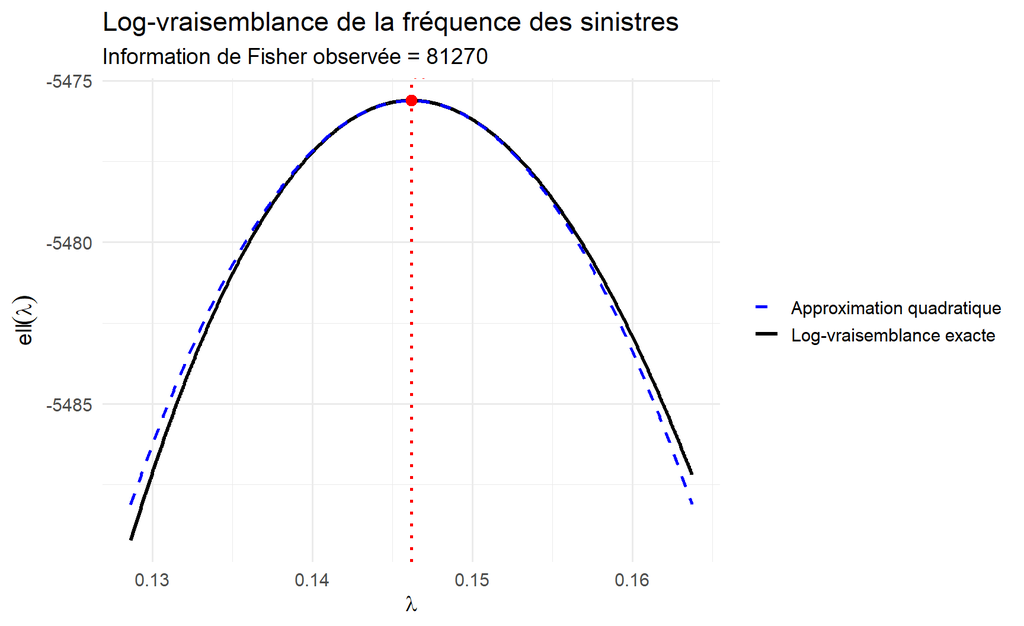

```r
lambdas <- seq(
  from = max(0.001, lambda_hat - 5 * erreur_standard_lambda_hat),
  to = lambda_hat + 5 * erreur_standard_lambda_hat,
  length.out = 1000
)

approximation_quadratique <- function(lambda) {
  loglik_hat -
    0.5 * information_observee * (lambda - lambda_hat)^2
}

plot_data <- data.frame(
  lambda = lambdas,
  log_vraisemblance = sapply(
    lambdas,
    loglik,
    exposures = exposures,
    claims = claims,
    policy_counts = policy_counts
  ),
  approximation_quadratique = approximation_quadratique(lambdas)
)

ggplot(plot_data, aes(x = lambda)) +
  geom_line(
    aes(y = log_vraisemblance, colour = "Log-vraisemblance exacte"),
    linewidth = 1.1
  ) +
  geom_line(
    aes(
      y = approximation_quadratique,
      colour = "Approximation quadratique"
    ),
    linewidth = 1,
    linetype = "dashed"
  ) +
  geom_vline(
    xintercept = lambda_hat,
    colour = "red",
    linetype = "dotted",
    linewidth = 1
  ) +
  geom_point(
    data = data.frame(
      lambda = lambda_hat,
      log_vraisemblance = loglik_hat
    ),
    aes(x = lambda, y = log_vraisemblance),
    inherit.aes = FALSE,
    colour = "red",
    size = 3
  ) +
  annotate(
    "text",
    x = lambda_hat,
    y = loglik_hat,
    label = expression(hat(lambda)),
    colour = "red",
    hjust = -0.2,
    vjust = -0.8,
    parse = TRUE,
    size = 5
  ) +
  scale_colour_manual(
    values = c(
      "Log-vraisemblance exacte" = "black",
      "Approximation quadratique" = "blue"
    )
  ) +
  labs(
    title = "Log-vraisemblance de la fréquence des sinistres",
    subtitle = paste(
      "Information de Fisher observée =",
      round(information_observee, 1)
    ),
    x = expression(lambda),
    y = expression(ell(lambda)),
    colour = NULL
  ) +
  theme_minimal(base_size = 14)
```

# Test du rapport de vraisemblance

Considérons le test :

$$H_0:\lambda=\lambda_0
\qquad \text{contre} \qquad
H_a:\lambda\neq\lambda_0.$$

La statistique du rapport de vraisemblance est :

$$-2\log\Lambda
=
2\left[
\ell(\widehat{\lambda})-\ell(\lambda_0)
\right].$$

Sous $H_0$, lorsque l’échantillon est suffisamment grand :

$$-2\log\Lambda
\overset{a}{\sim}
\chi^2_1.$$

Au seuil $\alpha$, on rejette $H_0$ lorsque :

$$-2\log\Lambda
>
\chi^2_{1,1-\alpha}.$$

## Exemple : test d’une fréquence tarifaire

Supposons que l’on souhaite tester l’hypothèse selon laquelle la fréquence annuelle vaut $0.15$ :

$$H_0:\lambda=0.15.$$

```r
lambda_0 <- 0.15
alpha <- 0.05

loglik_nulle <- loglik(
  lambda = lambda_0,
  exposures = exposures,
  claims = claims,
  policy_counts = policy_counts
)

statistique_rv <- 2 * (loglik_hat - loglik_nulle)
valeur_critique_rv <- qchisq(1 - alpha, df = 1)
p_value_rv <- pchisq(
  statistique_rv,
  df = 1,
  lower.tail = FALSE
)

resultats_rv <- data.frame(
  quantite = c(
    "Valeur sous H0 : lambda_0",
    "EMV : lambda_hat",
    "Statistique du rapport de vraisemblance",
    "Valeur critique à 5 %",
    "p-valeur"
  ),
  valeur = c(
    lambda_0,
    lambda_hat,
    statistique_rv,
    valeur_critique_rv,
    p_value_rv
  )
)

knitr::kable(resultats_rv, digits = 5)
```

| quantite | valeur |
| --- | --- |
| Valeur sous H0 : lambda_0 | 0.15000 |
| EMV : lambda_hat | 0.14620 |
| Statistique du rapport de vraisemblance | 1.15615 |
| Valeur critique à 5 % | 3.84146 |
| p-valeur | 0.28227 |

```r
if (p_value_rv < alpha) {
  cat(
    "Décision : rejet de H0 au seuil de",
    alpha * 100,
    "%.\n"
  )
} else {
  cat(
    "Décision : H0 n'est pas rejetée au seuil de",
    alpha * 100,
    "%.\n"
  )
}
```

```
## Décision : H0 n'est pas rejetée au seuil de 5 %.
```

## Représentation graphique du test du rapport de vraisemblance

La droite horizontale représente le niveau de log-vraisemblance à partir duquel une valeur de $\lambda$ n’est plus rejetée :

$$\ell(\lambda)
=
\ell(\widehat{\lambda})
-
\frac{1}{2}\chi^2_{1,0.95}.$$

Les valeurs de $\lambda$ situées sous cette droite sont rejetées par le test du rapport de vraisemblance au seuil de 5 %.

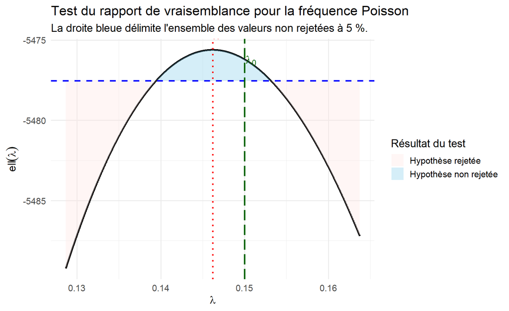

```r
seuil_loglik_rv <- loglik_hat - 0.5 * valeur_critique_rv

plot_data$accepte_par_rv <-
  plot_data$log_vraisemblance >= seuil_loglik_rv

ggplot(plot_data, aes(x = lambda, y = log_vraisemblance)) +
  geom_line(linewidth = 1.1, colour = "black") +
  geom_ribbon(
    aes(
      ymin = seuil_loglik_rv,
      ymax = log_vraisemblance,
      fill = accepte_par_rv
    ),
    alpha = 0.35
  ) +
  geom_hline(
    yintercept = seuil_loglik_rv,
    linetype = "dashed",
    colour = "blue",
    linewidth = 1
  ) +
  geom_vline(
    xintercept = lambda_hat,
    linetype = "dotted",
    colour = "red",
    linewidth = 1
  ) +
  geom_vline(
    xintercept = lambda_0,
    linetype = "longdash",
    colour = "darkgreen",
    linewidth = 1
  ) +
  annotate(
    "text",
    x = lambda_hat,
    y = max(plot_data$log_vraisemblance),
    label = expression(hat(lambda)),
    colour = "red",
    hjust = -0.1,
    vjust = -0.8,
    parse = TRUE,
    size = 5
  ) +
  annotate(
    "text",
    x = lambda_0,
    y = max(plot_data$log_vraisemblance),
    label = expression(lambda[0]),
    colour = "darkgreen",
    hjust = -0.1,
    vjust = 1.5,
    parse = TRUE,
    size = 5
  ) +
  scale_fill_manual(
    values = c(
      "TRUE" = "skyblue",
      "FALSE" = "mistyrose"
    ),
    labels = c(
      "TRUE" = "Hypothèse non rejetée",
      "FALSE" = "Hypothèse rejetée"
    )
  ) +
  labs(
    title = "Test du rapport de vraisemblance pour la fréquence Poisson",
    subtitle = "La droite bleue délimite l'ensemble des valeurs non rejetées à 5 %.",
    x = expression(lambda),
    y = expression(ell(lambda)),
    fill = "Résultat du test"
  ) +
  theme_minimal(base_size = 14)
```

# Test de Wald

La statistique de Wald pour tester $H_0:\lambda=\lambda_0$ est :

$$Z
=
\frac{\widehat{\lambda}-\lambda_0}
{\widehat{\operatorname{se}}(\widehat{\lambda})}.$$

Sous $H_0$,

$$Z
\overset{a}{\sim}
\mathcal{N}(0,1),$$

ou, de façon équivalente :

$$Z^2
\overset{a}{\sim}
\chi^2_1.$$

```r
statistique_wald_z <-
  (lambda_hat - lambda_0) / erreur_standard_lambda_hat

statistique_wald_chi2 <- statistique_wald_z^2

p_value_wald <- 2 * pnorm(
  abs(statistique_wald_z),
  lower.tail = FALSE
)

resultats_wald <- data.frame(
  quantite = c(
    "Statistique Z de Wald",
    "Statistique chi-deux de Wald",
    "p-valeur bilatérale"
  ),
  valeur = c(
    statistique_wald_z,
    statistique_wald_chi2,
    p_value_wald
  )
)

knitr::kable(resultats_wald, digits = 5)
```

| quantite | valeur |
| --- | --- |
| Statistique Z de Wald | -1.08451 |
| Statistique chi-deux de Wald | 1.17616 |
| p-valeur bilatérale | 0.27814 |

Pour un grand portefeuille, les tests du rapport de vraisemblance et de Wald donnent généralement des conclusions proches.

Le test du rapport de vraisemblance est toutefois souvent préférable lorsque la vraisemblance est asymétrique ou lorsque le paramètre est proche d’une frontière de l’espace paramétrique.

# Intervalles de confiance par inversion de tests

Un ensemble de confiance de niveau $100(1-\alpha)\%$ contient toutes les valeurs de paramètre pour lesquelles l’hypothèse nulle n’est pas rejetée par un test de niveau $\alpha$.

L’intervalle de confiance fondé sur le rapport de vraisemblance est :

$$\left\{
\lambda:
2\left[
\ell(\widehat{\lambda})-\ell(\lambda)
\right]
\leq
\chi^2_{1,1-\alpha}
\right\}.$$

```r
difference_rv <- function(lambda) {
  2 * (
    loglik_hat -
      loglik(
        lambda = lambda,
        exposures = exposures,
        claims = claims,
        policy_counts = policy_counts
      )
  ) - valeur_critique_rv
}

ic_rv_inferieur <- uniroot(
  difference_rv,
  interval = c(1e-10, lambda_hat)
)$root

ic_rv_superieur <- uniroot(
  difference_rv,
  interval = c(lambda_hat, max(1, 5 * lambda_hat))
)$root

ic_rv <- c(
  borne_inferieure = ic_rv_inferieur,
  borne_superieure = ic_rv_superieur
)

ic_rv
```

```
## borne_inferieure borne_superieure
##        0.1394252        0.1531909
```

L’intervalle de confiance de Wald est :

$$\widehat{\lambda}
\pm
z_{1-\alpha/2}
\widehat{\operatorname{se}}(\widehat{\lambda}).$$

```r
valeur_critique_normale <- qnorm(1 - alpha / 2)

ic_wald <- lambda_hat +
  c(-1, 1) * valeur_critique_normale * erreur_standard_lambda_hat

resultats_ic <- data.frame(
  methode = c(
    "Intervalle du rapport de vraisemblance",
    "Intervalle de Wald"
  ),
  borne_inferieure = c(ic_rv[1], ic_wald[1]),
  borne_superieure = c(ic_rv[2], ic_wald[2])
)

knitr::kable(resultats_ic, digits = 5)
```

|  | methode | borne_inferieure | borne_superieure |
| --- | --- | --- | --- |
| borne_inferieure | Intervalle du rapport de vraisemblance | 0.13943 | 0.15319 |
|  | Intervalle de Wald | 0.13932 | 0.15307 |

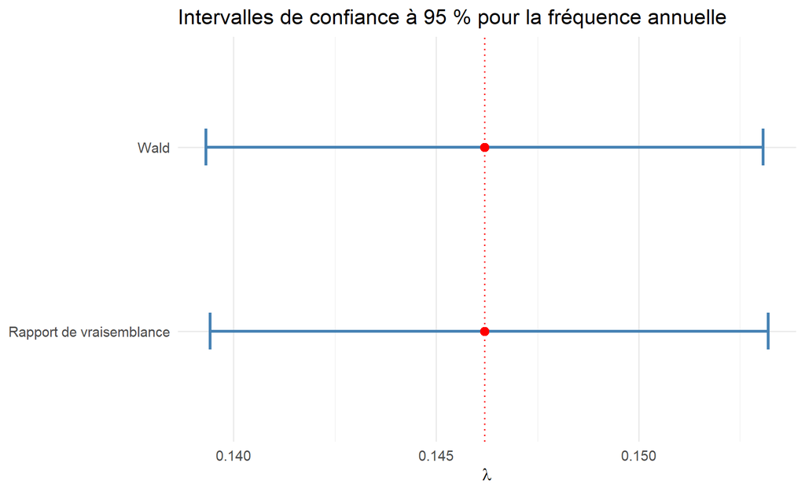

```r
ic_plot_data <- data.frame(
  methode = c("Rapport de vraisemblance", "Wald"),
  borne_inferieure = c(ic_rv[1], ic_wald[1]),
  borne_superieure = c(ic_rv[2], ic_wald[2]),
  estimation = lambda_hat
)

ggplot(ic_plot_data, aes(y = methode)) +
  geom_errorbarh(
    aes(
      xmin = borne_inferieure,
      xmax = borne_superieure
    ),
    height = 0.2,
    linewidth = 1.1,
    colour = "steelblue"
  ) +
  geom_point(
    aes(x = estimation),
    size = 3,
    colour = "red"
  ) +
  geom_vline(
    xintercept = lambda_hat,
    linetype = "dotted",
    colour = "red"
  ) +
  labs(
    title = "Intervalles de confiance à 95 % pour la fréquence annuelle",
    x = expression(lambda),
    y = NULL
  ) +
  theme_minimal(base_size = 14)
```

# Effet de l’exposition sur l’information de Fisher

Afin d’illustrer l’effet du volume de données, on multiplie simultanément :

- les nombres de polices ;
- les expositions totales.

Cette transformation conserve la fréquence empirique $\widehat{\lambda}$, mais modifie la quantité d’information disponible.

Dans ce modèle :

$$\mathcal{I}(\widehat{\lambda})
=
\frac{\sum_i d_i}{\widehat{\lambda}}.$$

L’information de Fisher augmente donc linéairement avec l’exposition totale, tandis que l’erreur standard diminue suivant :

$$\widehat{\operatorname{se}}(\widehat{\lambda})
\propto
\frac{1}{\sqrt{\sum_i d_i}}.$$

```r
scenarios <- data.frame(
  scenario = c(
    "Un quart du portefeuille",
    "Portefeuille observé",
    "Dix fois le portefeuille"
  ),
  multiplicateur = c(0.25, 1, 10)
)

resultats_scenarios <- do.call(
  rbind,
  lapply(seq_len(nrow(scenarios)), function(i) {

    multiplicateur <- scenarios$multiplicateur[i]

    expositions_ajustees <- exposures * multiplicateur
    polices_ajustees <- policy_counts * multiplicateur

    exposition_totale_ajustee <- sum(expositions_ajustees)
    sinistres_totaux_ajustes <- sum(claims * polices_ajustees)

    lambda_hat_ajuste <-
      sinistres_totaux_ajustes / exposition_totale_ajustee

    information_ajustee <-
      exposition_totale_ajustee / lambda_hat_ajuste

    erreur_standard_ajustee <- sqrt(1 / information_ajustee)

    data.frame(
      scenario = scenarios$scenario[i],
      multiplicateur = multiplicateur,
      exposition_totale = exposition_totale_ajustee,
      lambda_hat = lambda_hat_ajuste,
      information_fisher = information_ajustee,
      erreur_standard = erreur_standard_ajustee,
      ic_inferieur =
        lambda_hat_ajuste -
        valeur_critique_normale * erreur_standard_ajustee,
      ic_superieur =
        lambda_hat_ajuste +
        valeur_critique_normale * erreur_standard_ajustee
    )
  })
)

knitr::kable(resultats_scenarios, digits = 5)
```

| scenario | multiplicateur | exposition_totale | lambda_hat | information_fisher | erreur_standard | ic_inferieur | ic_superieur |
| --- | --- | --- | --- | --- | --- | --- | --- |
| Un quart du portefeuille | 0.25 | 2970.332 | 0.1462 | 20317.50 | 0.00702 | 0.13245 | 0.15995 |
| Portefeuille observé | 1.00 | 11881.330 | 0.1462 | 81270.01 | 0.00351 | 0.13932 | 0.15307 |
| Dix fois le portefeuille | 10.00 | 118813.300 | 0.1462 | 812700.07 | 0.00111 | 0.14402 | 0.14837 |

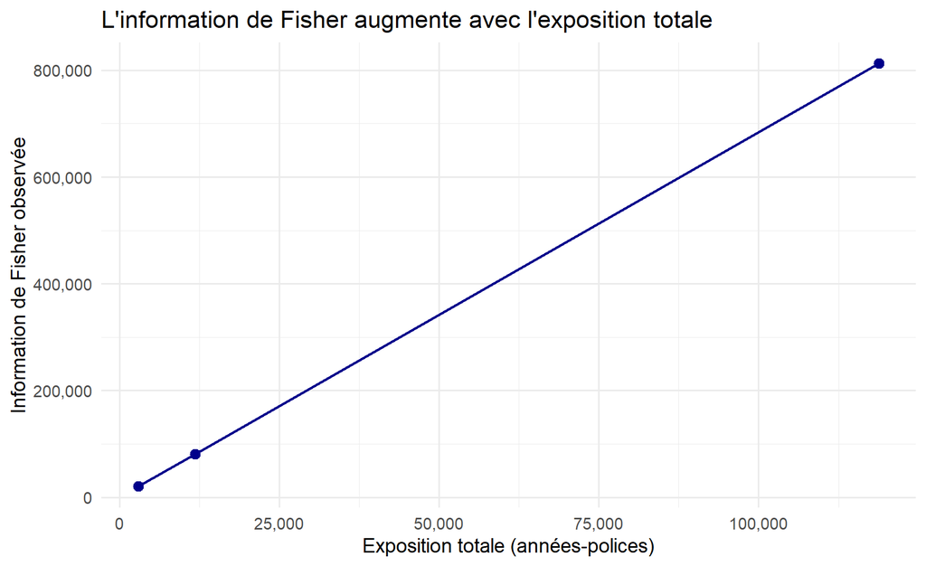

```r
ggplot(
  resultats_scenarios,
  aes(x = exposition_totale, y = information_fisher)
) +
  geom_point(size = 3, colour = "darkblue") +
  geom_line(linewidth = 1, colour = "darkblue") +
  scale_x_continuous(labels = comma) +
  scale_y_continuous(labels = comma) +
  labs(
    title = "L'information de Fisher augmente avec l'exposition totale",
    x = "Exposition totale (années-polices)",
    y = "Information de Fisher observée"
  ) +
  theme_minimal(base_size = 14)
```

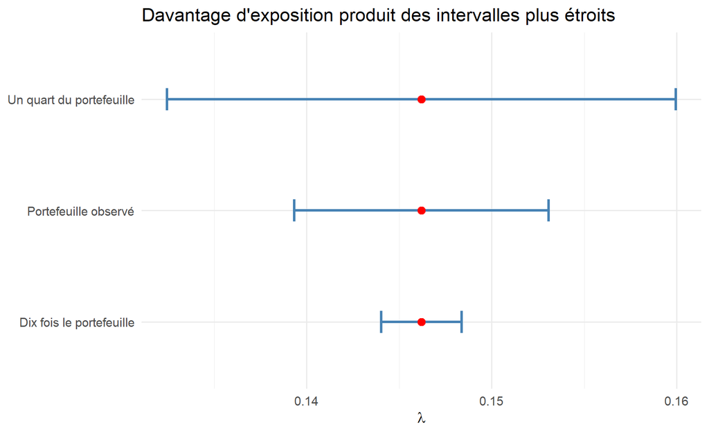

```r
ggplot(resultats_scenarios, aes(y = scenario)) +
  geom_errorbarh(
    aes(xmin = ic_inferieur, xmax = ic_superieur),
    height = 0.2,
    linewidth = 1.1,
    colour = "steelblue"
  ) +
  geom_point(
    aes(x = lambda_hat),
    size = 3,
    colour = "red"
  ) +
  labs(
    title = "Davantage d'exposition produit des intervalles plus étroits",
    x = expression(lambda),
    y = NULL
  ) +
  theme_minimal(base_size = 14)
```

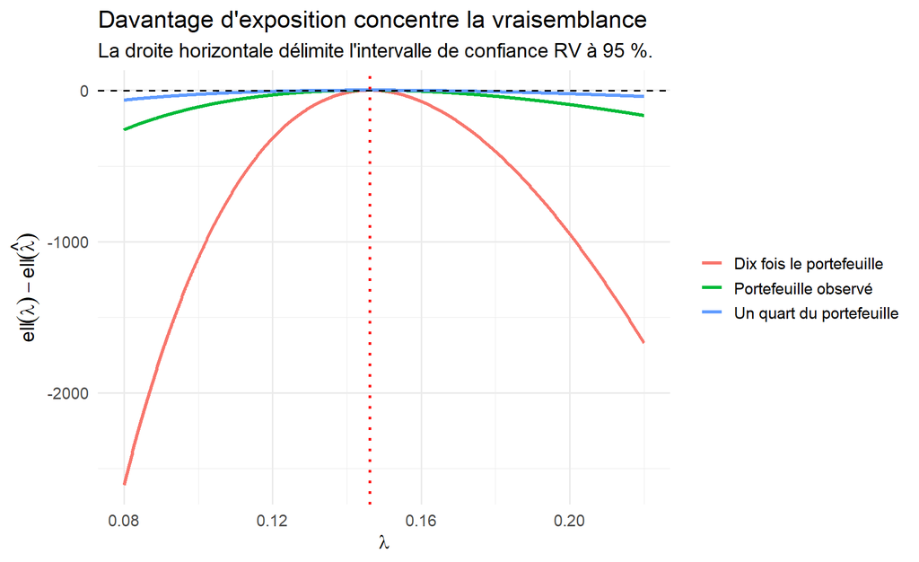

```r
lambdas <- seq(0.08, 0.22, length.out = 1000)

scenarios_vraisemblance <- do.call(
  rbind,
  lapply(seq_len(nrow(scenarios)), function(i) {

    multiplicateur <- scenarios$multiplicateur[i]

    expositions_ajustees <- exposures * multiplicateur
    polices_ajustees <- policy_counts * multiplicateur

    lambda_hat_ajuste <-
      sum(claims * polices_ajustees) / sum(expositions_ajustees)

    loglik_values <- sapply(
      lambdas,
      loglik,
      exposures = expositions_ajustees,
      claims = claims,
      policy_counts = polices_ajustees
    )

    loglik_emv <- loglik(
      lambda = lambda_hat_ajuste,
      exposures = expositions_ajustees,
      claims = claims,
      policy_counts = polices_ajustees
    )

    data.frame(
      lambda = lambdas,
      log_vraisemblance_relative = loglik_values - loglik_emv,
      scenario = scenarios$scenario[i]
    )
  })
)

ggplot(
  scenarios_vraisemblance,
  aes(
    x = lambda,
    y = log_vraisemblance_relative,
    colour = scenario
  )
) +
  geom_line(linewidth = 1.1) +
  geom_hline(
    yintercept = -0.5 * valeur_critique_rv,
    linetype = "dashed"
  ) +
  geom_vline(
    xintercept = lambda_hat,
    colour = "red",
    linetype = "dotted",
    linewidth = 1
  ) +
  labs(
    title = "Davantage d'exposition concentre la vraisemblance",
    subtitle = "La droite horizontale délimite l'intervalle de confiance RV à 95 %.",
    x = expression(lambda),
    y = expression(
      ell(lambda) - ell(hat(lambda))
    ),
    colour = NULL
  ) +
  theme_minimal(base_size = 14)
```

# Messages principaux

1. La courbure de la log-vraisemblance au niveau de l’EMV est l’information de Fisher observée :

   $$\mathcal{J}(\widehat{\lambda})
   =
   -\ell''(\widehat{\lambda}).$$
2. Une exposition totale plus importante augmente l’information de Fisher et réduit l’erreur standard de $\widehat{\lambda}$.
3. Le test du rapport de vraisemblance compare la vraisemblance de l’EMV avec celle obtenue sous une valeur imposée par l’hypothèse nulle :

   $$-2\log\Lambda
   =
   2\left[
   \ell(\widehat{\lambda})-\ell(\lambda_0)
   \right].$$
4. Un intervalle de confiance peut être construit en conservant toutes les valeurs de paramètre qui ne sont pas rejetées par un test d’hypothèse.
5. Dans ce modèle Poisson à un paramètre et pour un grand portefeuille, les intervalles de Wald et du rapport de vraisemblance sont proches.
6. Dans des modèles plus complexes, notamment lorsque la vraisemblance est asymétrique, les intervalles fondés sur le profil de vraisemblance sont souvent plus fiables que les intervalles de Wald.